# General Social Survey

# 2 Introduction Question 2

Now answer Is belief in the bigbang theory (BIGBANG) independent of belief in the afterlife (POSTLIFE)

## 2.1 Methods

$H-0$: “The BIGBANG theory has no relationship to POSTLIFE. $H-A$ :”There’s a relation between the BIGBANG theory and POSTLIFE.

## 2.2 Results

### 2.2.1 Descriptive Results

#### 2.2.1.1 Graphical Descriptive Results

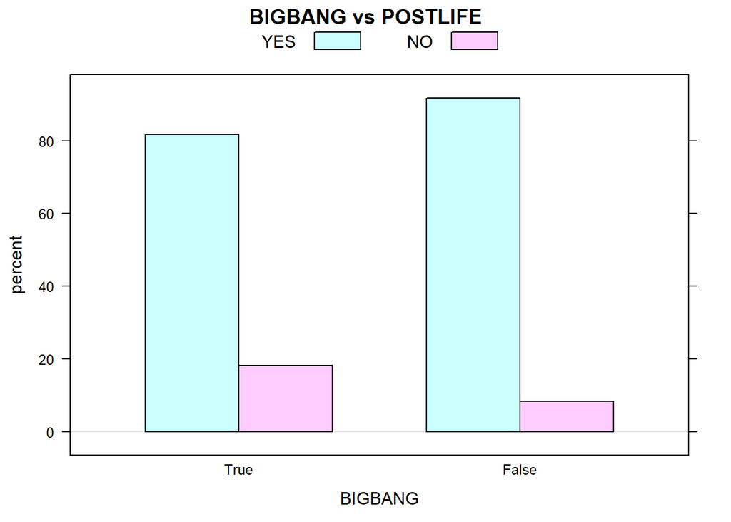

```r
barchartGC(~BIGBANG+POSTLIFE, data = mydata4, type = "percent", xlab= "BIGBANG", main = "BIGBANG vs POSTLIFE")
```

This graph shows that those that believe in the big bang theory. the proportion of those that believe in an afterlife is about the same as those who dont believe the big bang theory.

#### 2.2.1.2 Numerical Descriptive Results

```r
tab2 = xtabs(formula = ~BIGBANG+POSTLIFE, data = mydata4)
rowPerc(tab2)
```

```
##        POSTLIFE
## BIGBANG    YES     NO  Total
##   True   81.71  18.29 100.00
##   False  91.67   8.33 100.00
```

```r
chisqtestGC(tab2)
```

```
## Pearson's Chi-squared test with Yates' continuity correction
##
## Observed Counts:
##        POSTLIFE
## BIGBANG YES NO
##   True   67 15
##   False  88  8
##
## Counts Expected by Null:
##        POSTLIFE
## BIGBANG  YES   NO
##   True  71.4 10.6
##   False 83.6 12.4
##
## Contributions to the chi-square statistic:
##        POSTLIFE
## BIGBANG  YES   NO
##   True  0.27 1.83
##   False 0.23 1.56
##
##
## Chi-Square Statistic = 3.0637
## Degrees of Freedom of the table = 1
## P-Value = 0.0801
```

# 3 Introduction Question 3

Finally determine if a persons opinion on death penalty (CAPPUN) is independent of their race (RACE).

## 3.1 Methods

$H-0$: “The CAPPUN has no relationship to RACE. $H-A$ :”There’s a relation between the CAPPUN and RACE.

## 3.2 Results

### 3.2.1 Descriptive Results

#### 3.2.1.1 Graphical Descriptive Results

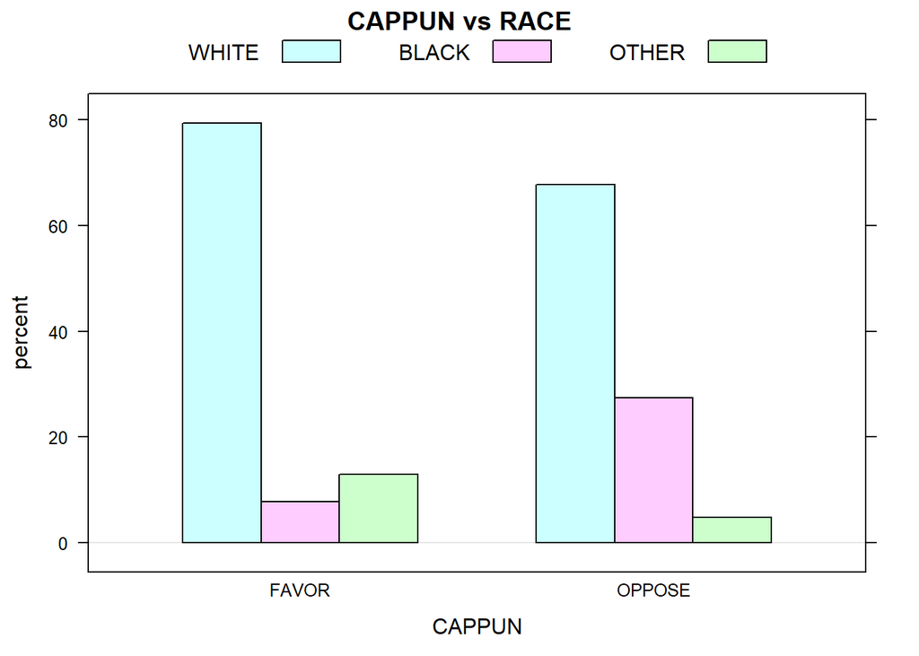

```r
barchartGC(~CAPPUN+RACE, data = mydata4, type = "percent", xlab= "CAPPUN", main = "CAPPUN vs RACE")
```

Those that favor capital pun in this case tend to be a smaller proportion of blacks while other races favor cappun.

#### 3.2.1.2 Numerical Descriptive Results

```r
tab2 = xtabs(formula = ~CAPPUN+RACE, data = mydata4)
rowPerc(tab2)
```

```
##         RACE
## CAPPUN    WHITE  BLACK  OTHER  Total
##   FAVOR   79.31   7.76  12.93 100.00
##   OPPOSE  67.74  27.42   4.84 100.00
```

### 3.2.2 Inferential Results

```r
chisqtestGC(tab2)
```

```
## Pearson's Chi-squared test
##
## Observed Counts:
##         RACE
## CAPPUN   WHITE BLACK OTHER
##   FAVOR     92     9    15
##   OPPOSE    42    17     3
##
## Counts Expected by Null:
##         RACE
## CAPPUN   WHITE BLACK OTHER
##   FAVOR  87.33 16.94 11.73
##   OPPOSE 46.67  9.06  6.27
##
## Contributions to the chi-square statistic:
##         RACE
## CAPPUN   WHITE BLACK OTHER
##   FAVOR   0.25  3.72  0.91
##   OPPOSE  0.47  6.97  1.71
##
##
## Chi-Square Statistic = 14.0272
## Degrees of Freedom of the table = 2
## P-Value = 9e-04
```

# 4 Discussion and Conclusion

Reject the null hypothesis. There is a relataionship between race and opinion on cappun in this case. The Pval was .0009<.05. Therefore, we have strong evidence of a relationship between race and view on cappun.